# ETC5521 Assignment 1

Samuel Lyubic

Yuheng

2020-09-18

This assignment is for ETC5521 Assignment 1 by Team Possum comprising of Samuel Lyubic and Yuheng.

# 1 Introduction and motivation

Volcanoes date back to hundreds and thousands of years ago where the first documented eruption occurred in [Santorini back in 1650 BC!](https://books.google.com.au/books?hl=en&lr=&id=pcucBAAAQBAJ&oi=fnd&pg=PP1&dq=volcanoes&ots=k2yBX9ZjWf&sig=bG4X4uLpUyqGG4DQH8BTgI7AK58&redir_esc=y#v=snippet&q=first%20eruption&f=false) Accompanied by its mysterious image in our eyes, volcanoes touch on a wide range of knowledge, including geochemistry, petrology, seismology and more. This topic seems to be complex and distant from people like us who did not take further studies on this area. Yet we chanced upon data set released by `TidyTuesday` which is probably one of if not the most comprehensive data set to learn more about volcanoes. This data exploration enable us to take a closer look at the more recent active volcanoes around.

Although volcanoes are nature’s explosive land forms and yet one of the most beautiful, it is inevitable for us, as human being to neglect its impact on our lives. Based on our understanding on volcanoes, we develop two themes that will be surrounding this entire analysis, which are “severity” and “safety” so as to establish more interesting facts!

We start with a brief introduction into the world of volcanoes, then visit the interaction between volcano & humans and finally looking into the characteristics of volcano.

# 2 Data description

The data source is from [The Smithsonian Institution](https://volcano.si.edu/), which has been constantly updating since 2013. The data is cleaned and made available for download on (https://github.com/rfordatascience/tidytuesday/blob/master/data/2020/2020-05-12/readme.md), so that we directly import the 5 data sets for this analysis. These 5 data sets are probably the most comprehensive data set around. They are volcano, eruptions, events, tree_rings and sulfur, allowing us to discover the influences among them.

The data source is from [The Smithsonian Institution](https://volcano.si.edu/). The data is available, and cleaned, downloadable from [tidytuesday github](https://github.com/rfordatascience/tidytuesday/blob/master/data/2020/2020-05-12/readme.md). Cleaning script is also supplied.

Data provided contains 5 linked data sets, each with looking at a particular aspect of volcano:

# 3 Research questions

- Primary: Does volcanoes with different VEI have specific characteristics?
- Secondary: How worried should you be about a volcano eruption? Which tectonic settings have higher or lower VEI and how this relates to the duration of eruption? What is the ideal setting for a volcano to form?

# 4 Analysis and findings

## 4.1 World Of Active Volcanoes

### 4.1.1 World Map of Active Volcanoes erupt

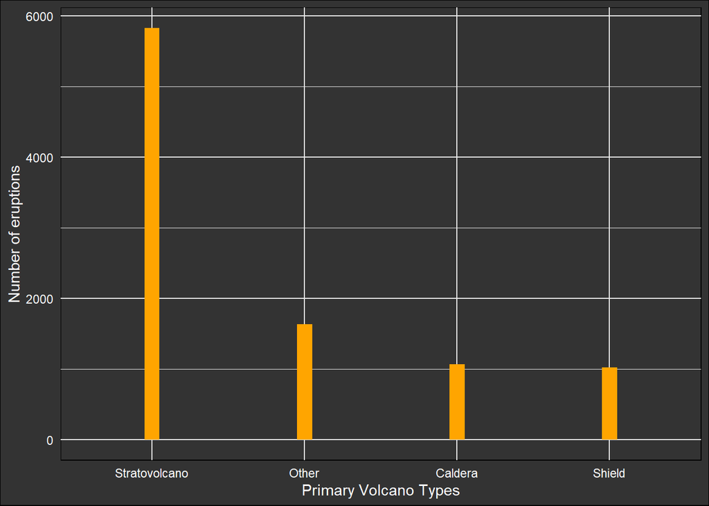

Figure 4.1: Number of eruptions for Primary Volcano Types

There are 3 main types of Active(erupted before) Volcanoes namely Stratovolcano, Caldera and Shield. We decided to label the others as `others`. Stratovolcanoes are by far the most active volcano.

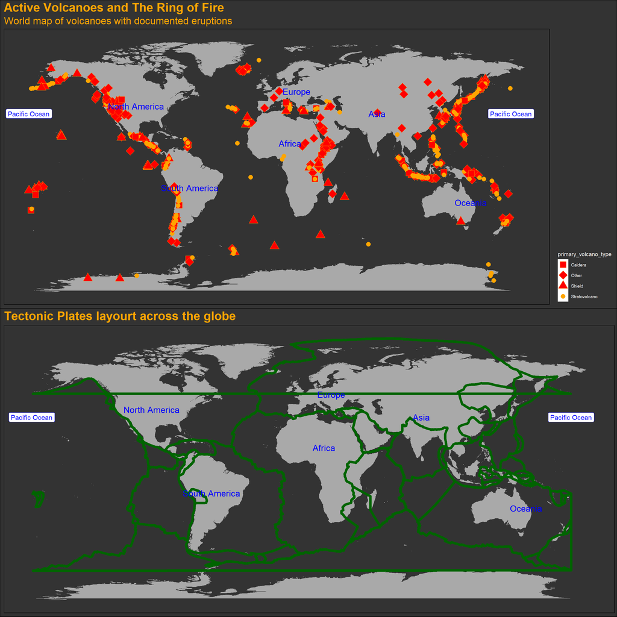

Figure 4.2: Active Volcanoes and The Ring of Fire, and Tectonic Plates layourt across the globe

Figure 4.2 displays two maps, one showing the Active Volcanoes and the ring of fire and the other showing the layour of tectonic plate boundaries.

We found that most of the volcanoes lie along the Pacific Ocean tracing the boundaries of tectonic plates, this is known as the ‘Ring of Fire’ (Society 2019). This path is approximately 40,000km long and holds 75% of the World’s Volcanoes with 90% of them being active. The abundance of volcanoes are explained by significant tectonic plates in the area, as volcanoes are formed through the cracking in the ground created by converging or diverging tectonic plate boundaries.

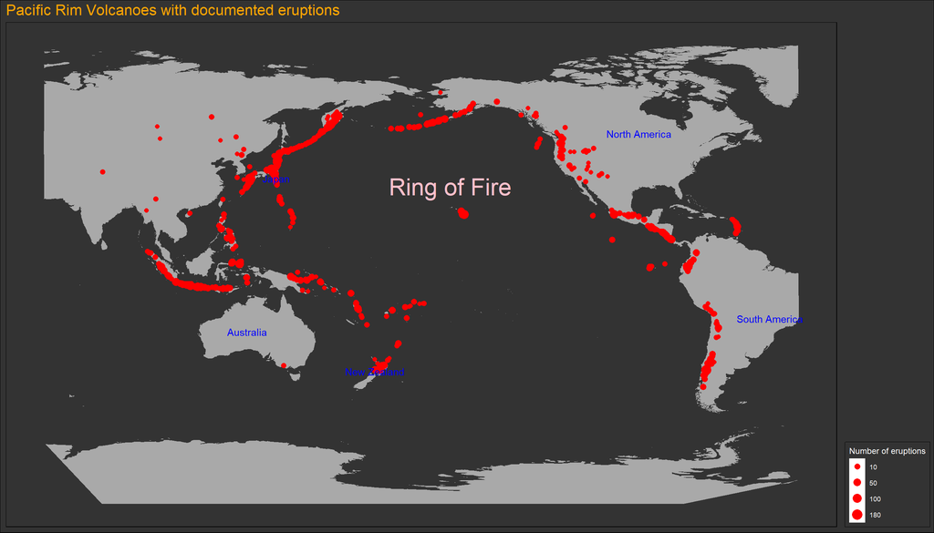

Figure 4.3: The Ring of Fire

This map zoomed into the Ring Of Fire, showing the volcanoes running along the boundaries. Relatively speaking, the volcanoes here have more eruptions.

## 4.2 The interaction between volcanoes and humans - How worried should you be about volcanoes?

### 4.2.1 Population around volcanoes’ vicinity

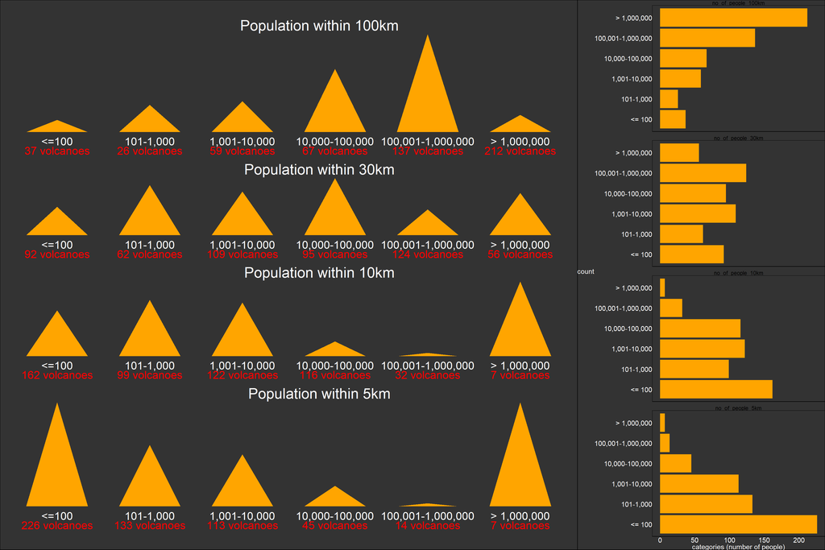

Figure 4.4: Population within 5, 10, 30, 100km from Volcano

- Population size with 5km is mostly less tehn 100
- However, within a 10km range there is quite a bit of variability in the sizes of the populations in that range.

The impact of a volcano can vary in their destructive nature, creating both immediate and long term risks to the surrounding and global populations. The immediate risk to the surrounding populations come in the physical form of:

- *Pyroclastic flows*, which is the extremely hot chaotic mixture of rock fragments, gas, and ash that travels rapidly from an eruption and destroys whats in its path
- *Projectile fragments*, fragments of rock that can travel anywhere from 100m to 25km depending on the size and magnitude of the eruption
- *Heavy ash* which are clouds consisting of small particles of gases and rocks around the 2mm in size, that are released into the atmosphere and then landing on the ground.

Size of a volcano can be an indicator of the potential damage that could come from an eruption given the positioning and greater velocity that can be prodcued from a larger volcano however, there is no way to create a blanket safe distance rule when it comes to their damage radius is the impact of a volcano uniqely dependent on each individual eruption. Generally, 5-10km range is relatively safe for residincy given the size of most eruptions however, as only an exceptional eruption would result in severe in that range, although these “exceptional eruptions” are not too uncommon for residents who decide to live in this proximity to setup imobile residencies. [Volcanic Discovery](https://www.volcanodiscovery.com/volcanic_risk_zones.html#:~:text=4)%20Low%20Risk%20Zone&text=Typically%20you%20are%20more%20than,pyroclastic%20flows%20could%20be%20channeled.)

Figure 4.4 was inspired by [Sil Aarts’](https://twitter.com/sil_aarts/status/1260156344319041537/photo/1) visualization where we use `geom_polygon` to create easy and intuitive visualizations.

### 4.2.2 World map with number of eruptions in each country

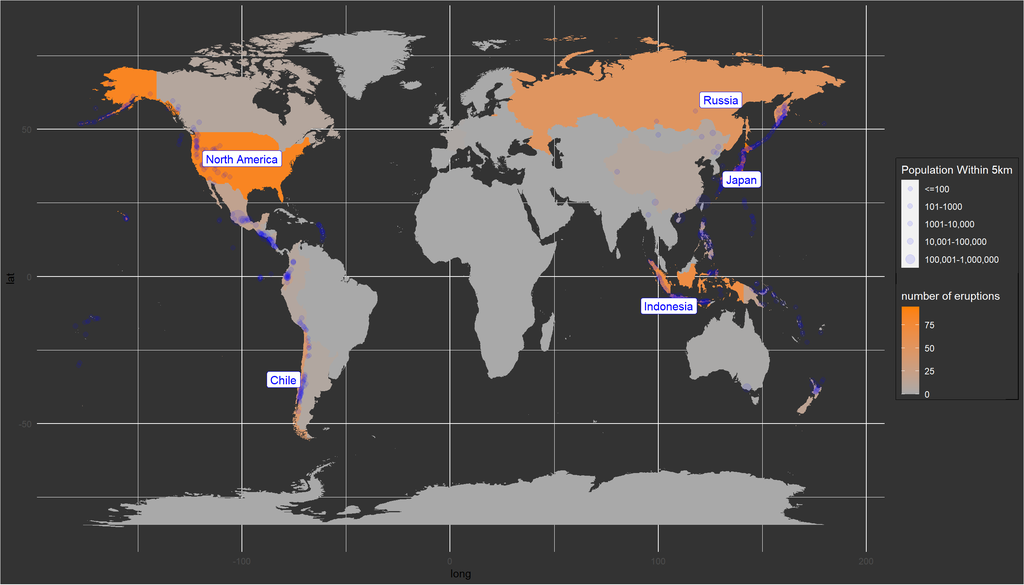

Figure 4.5: World Map with countries experiencing most eruptions

Figure 4.5 displays the locations of volcanoes with a populations within a 5km radius, with the size of the population mapped to size of the point and orange scale indicating the number of volcano eruptions across the glove. with fill depending on the number of eruptions in each country and larger dot sizes represent the number of population in the vicinity.

- Most of the countries with higher counts of eruptions lie along the edges of the pacifc ocean, which is known as the “Ring of Fire”
- The countries along the “Ring of Fire”, specifically Noth America, Chile, Indonesia and Japan have the highest number of populations near the more active volcano sites. Inicating that, living in those countries along the pacific ocean poses a potential higher risk to those individuals relative to those living more inland.[https://www.usgs.gov/faqs/what-ring-fire?qt-news_science_products=0#]

## 4.3 Which VEI rating eruptions are most likely?

### 4.3.1 How prominent are high VEI scale eruptions?

VEI measures the explosiveness of volcanic eruptions which is determined by the volume of contents launched from the eruption. The contents is made up of pyroclastic flow, ash clouds, debrit and rocks with the eruption cloud height and volume being assessed as part of the measure. VEI is qualitatlively described using terms such ranging from “gentle” to “mega-colossal”. [[Wikipedia](https://en.wikipedia.org/wiki/Volcanic_Explosivity_Index)].

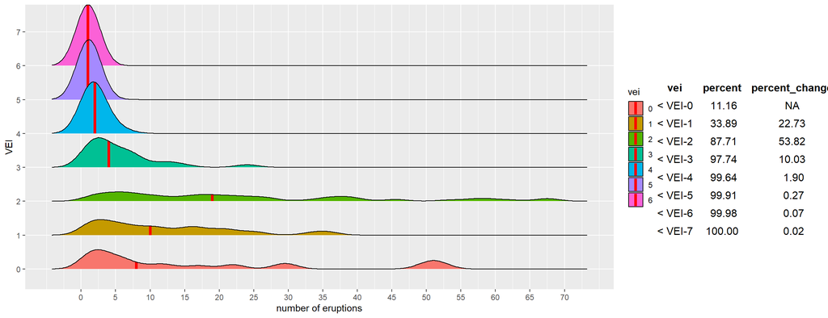

Figure 4.6: Probability density function of eruptions in each VEI category

Theoretically, VEI ranges from 0 to infinity. In this dataset VEI has been recorded on a log10 scale, thereby each interval (increase of 1 in VEI) indicates an eruption 10x the magnitude. There only bee 40 eruptions over the last 132 million years that recorded a VEI-8 magnitude eruption and only in the last 10,000 years, only 10 eruptions have recorded a VEI-7.

Figure 4.6 presents the number of eruptions for the recorded VEI eruptions since 1812, with the number of eruptions on the x axis and the VEI rating on the y axis. The figure shows:

- VEI 7 has only one observation since 1812, which occured on Mount Tambora
- The likelihood of a volcano with VEI 4 or above is very unlikely (less than 1). In fact, almost 98% of all volcanoes have less than VEI-3.
- Eruptions with a rating of VEI-2 occur relatively more frequently with quite a number of them occurring > 50 times over the time span.

### 4.3.2 How Frequently do volcanoes erupt?

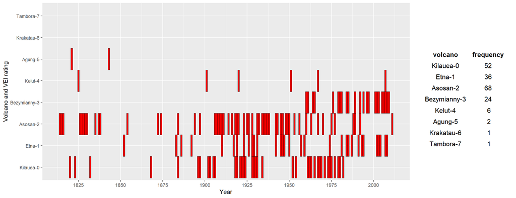

Figure 4.7: Frequency of Most Active Volcanoes in each VEI category

Figure 4.7 displays the volcanoes with the largest count of eruptions for each VEI rating presented in Figure 4.6. The frequency of eruptions are shown by the red tiles, with each tile representing an eruption, the year along the x axis with the name of the volcano and the corresponding VEI rating on the y axis.

### 4.3.3 How is VEI level related to eruption duration?

Table 4.1: Five number summary and mean of duration for each VEI

| 0 | 1 | 2 | 3 | 4 | 5 | 6 | VEI |
| --- | --- | --- | --- | --- | --- | --- | --- |
| 0.0000 | 0.0000 | 0.0000 | 0.000 | 0.0000 | 3.0000 | 18.00 | Min |
| 1.5000 | 0.0000 | 10.7500 | 27.000 | 23.0000 | 32.5000 | 18.75 | Q1 |
| 14.0000 | 12.0000 | 59.0000 | 105.500 | 82.0000 | 75.0000 | 86.00 | Median |
| 147.9272 | 145.6442 | 284.4049 | 1154.176 | 592.9333 | 382.2857 | 86.00 | Mean |
| 94.0000 | 98.5000 | 204.0000 | 592.500 | 354.0000 | 246.5000 | 153.25 | Q3 |
| 2774.0000 | 7128.0000 | 31486.0000 | 35729.000 | 11082.0000 | 2406.0000 | 154.00 | Max |

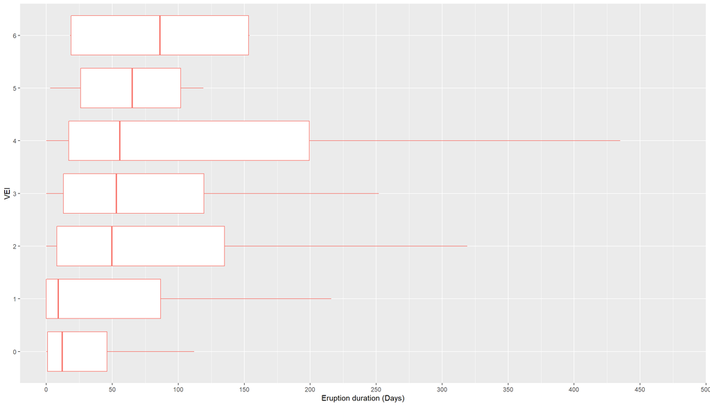

Figure 4.8: Five number summary distribtuion for VEI level from 0 to 6

Figure 4.8 visualises the distribtuon of eruption day length for each VEI rating category, with eruption duration, in days, on the x axis and the VEI rating on y-axis. The outliers have been removed for more interpretable results. It is evident with the ommission of outliers that:

- For all VEI ratings the eruptions lasted less then 500 days with the outliers excluded.
  - Rating 6 VEI has the longest median duration relative to the other ratings.
  - VEI rating of 1 has the shortest median duration.
  - VEI rating 4 has the largest range of duration out of all the eruptions across each VEI rating
  - VEI rating 6 has a maximum duration of 154 days which is lower then the maximum durations of VEI rating 1, 2, 3 and 4.

Table 4.2: Goodness of fit measure for VEI and duration

| r.squared | adj.r.squared |
| --- | --- |
| 0.0162597 | 0.0156502 |

Table 4.2 displays the results for the goodness of fit analysis conducted in order examine the relationship between VEI and duration.

- r-square and adjusted r-squared are low with 1.63% and 1.57%.
  - This implies that only 1.63% of the variation in duration can be explained by a VEI level, if a regression model is fitted, thus concluding the insignificant role of VEI in determining duration.

### 4.3.4 Which tectonic settings have longer or shorter eruption duration?

The following section will be analysis the duration of eruptions for the range of tectonic settings.

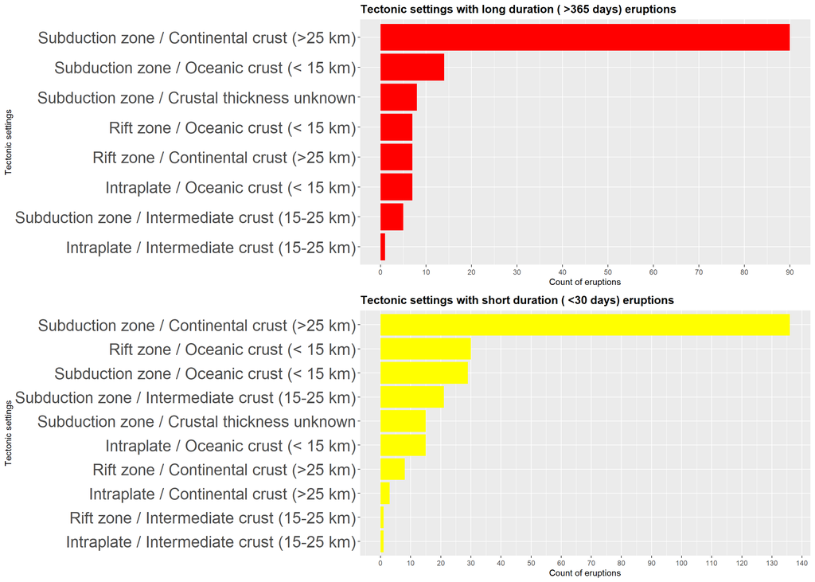

Figure 4.9: Eruption duration across the range of tectonic settings

Figure 4.9 displays two figures, one for tectonic settings with long durations - greater then 365 days, and another for short durations - less then 30 days, with the count of the number of eruptions across the range of tectonic plates along the x axis and the tectonic setting on the y axis.

For long eruption durations:

- Subduction zone / Continental crust ( >25km) has the most erupations with the longest duration, making up 58.82% of the erupations that lasted longer then 365 days. It stands far out in front of the next closest tectonic setting which is Subduction zone / Oceanic crust ( <15km) with 14 recorded long eruptions.
  - The remaining tectonic settings have very close figures, as well as proportions with Intraplate / Intermediate crust (15-25 km) showing to have the least number of long eruptions. For short eruption durations:
  - Similarly to the long duration, Subduction zone / Continential crust (>25km) has by far the largest number of short duration eruptions and Intraplate / Intermediate crust (15-25km) has the least number of short duration eruptions
  - There is variation in the middle order of tectonic settings relative to the long duration figure with only 7 long duration eruptions (4.575%) on Rift zone / Oceanic crust ( <15km), however the number of short duration eruptions rises to 30, accounting for 10.067% among all tectonic settings.

Moreover, comparing the count figures, it is apparent that every number from long duration eruptions for all tectonic settings increase when it comes to short duration thus indicating that short duration eruptions occur more frequently than longer ones.

### 4.3.5 What are the eruption frequencies associated with the range of tectonic settings?

The following section will be analysing which how frequently each tectonic setting erupts, specifically assessing high frequency counts that involve two or more eruptions per year,

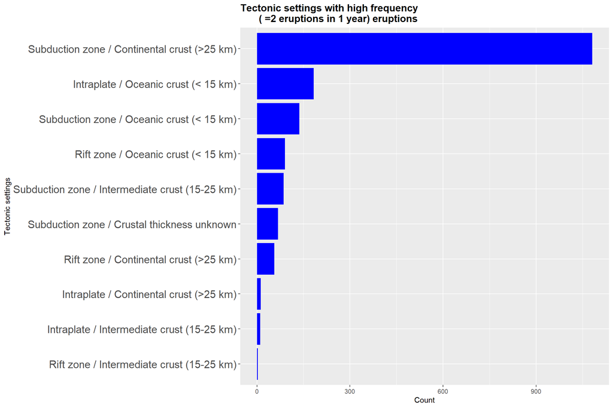

Figure 4.10: The high or low frequncies associated with the range of tectonic settings

### 4.3.6 Discussion on tectonic settings and average VEI

Grouped by 10 tectonic settings (NAs excluded), volcano eruptions on Rift zone / Intermediate crust (15-25 km) have the highest average VEI of 2.667, whereas those located on Intraplate / Oceanic crust ( <15 km) obtain the lowest average VEI of 0.923. Furthermore, as shown by Figure 4.9, despite Subduction zone / Continental crust ( >25km) having most longer ( >365 days) and shorter duration ( <30 days) eruptions occur as well as having the most higher frequency ( ≥ 2 eruptions within 1 year) of eruptions, it does not incur a high average VEI. It instead lies in the middle range among the 10 tectonic settings, with the average VEI of 1.982.

Table 4.3: Average VEI level for each tectonic setting

| tectonic_settings | Avg vei |
| --- | --- |
| Rift zone / Intermediate crust (15-25 km) | 2.667 |
| Intraplate / Continental crust (>25 km) | 2.250 |
| Subduction zone / Intermediate crust (15-25 km) | 2.195 |
| Rift zone / Oceanic crust (< 15 km) | 2.132 |
| Intraplate / Intermediate crust (15-25 km) | 2.091 |
| Subduction zone / Continental crust (>25 km) | 1.982 |
| Subduction zone / Oceanic crust (< 15 km) | 1.796 |
| Rift zone / Continental crust (>25 km) | 1.714 |
| Subduction zone / Crustal thickness unknown | 1.623 |
| Intraplate / Oceanic crust (< 15 km) | 0.923 |

# 5 Assignment 2 Extra questions

## 5.1 Is there any relationship between tree rings and volcanic eruption events? (Edited by Yuheng Cui)

Tree ring is an important indicator to reveal climate and temperature change. `tree_rings` dataset contains the values of two variables (`n_tree` and `europe_temp_index`) from year 0 to year 2000. `n_tree` is tree ring z-scores relative to year and z-score is a measure of variability from the mean). `europe_temp_index` is the average yearly temperature for Europe in Celsius relative to 1961 to 1990. We know that tree ring width reflects the growth conditions of the tree — the condition refers to nutrient conditions, precipitation and temperature during a growing season. Seiler, Houlié, and Cherubini (2017) suggest “the ring width may also be influenced by volcanic activity on Mount Etna and in other volcanic regions.” Seiler, Houlié, and Cherubini (2017) also suggest the pre-eruptive phase can only have begun when the trees had already ceased their seasonal growth.

### 5.1.1 Limitation of `tree_ring` dataset

`tree_ring` dataset does not have the accurate tree ring z-score value near the volcanoes, and the temperature index is related to only Europe but not near the active volcanoes. The second limitation is because wildfires also affect the tree ring z-score, but we don’t have the wildfires records of Europe.

Due to `tree_ring` dataset only containing the temperature index and tree ring data in Europe, we filter the eruption events that occur in Europe only. However, most eruption events were in Russia, and partial Russian territory is belong to Europe. In other words, not all eruptions affect Europe temperature index. But it is still worthy to analyse the relationship between tree rings and volcanic eruption events by using the `tree_ring` dataset.

### 5.1.2 Analysis

First, we draw a plot for `n_tree` and `europe_temp_index`. Fig 5.1 shows these the changes of two variables along time. The vertical dash lines indicate the eruption events. It seems that two lines generally fit each other. To ensure the correlation between these two variables, we run a correlation test. Table 5.1 shows the estimated correlation is 0.79 and p-value is less than 0.05. This is to say that we are 95% confident that two variables are strongly correlated. Thus, we can build a model for these two variables.

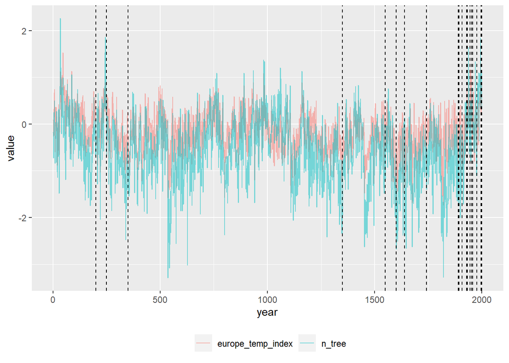

Figure 5.1: Tree ring z-score and temperature index

Table 5.1: Correlation test for tree ring z-score and temperature index

| estimate | statistic | p.value | parameter | conf.low | conf.high | method | alternative |
| --- | --- | --- | --- | --- | --- | --- | --- |
| 0.7931274 | 58.20812 | 0 | 1998 | 0.7762827 | 0.8088402 | Pearson’s product-moment correlation | two.sided |

We build two linear models:
$$\large{lm\_1} :\large{\widehat{\text{Europe temp index}}} = 0.1073 + 0.4941 * \text{Tree ring z-score}$$

$$\large{lm\_2} :\large{\widehat{\text{Europe temp index}}} = 0.10765 + 0.49421 * \text{Tree ring z-score} - 0.02598 * \text{Eruption}$$
In `lm_2`, for `eruption`, 1 means there was an eruption while 0 means none.

Table 5.2: Compare two models

| model | r_square |
| --- | --- |
| lm_1 (no eruption) | 0.6288653 |
| lm_2 (eruption) | 0.6287130 |

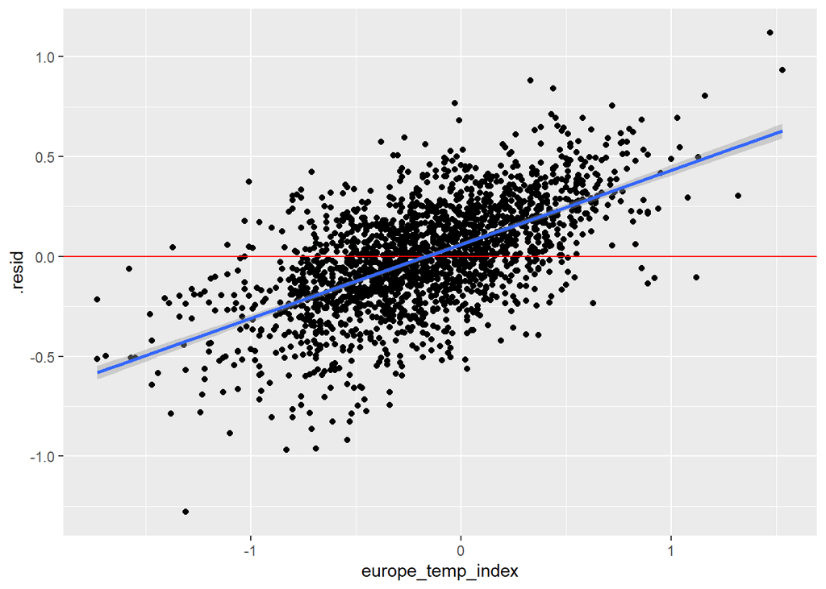

# 6 Acknowledgements

Data source is from Institution (n.d.).

In order to map the tectonic boundaries the tectonic plates were split at the prime meridian (x-intercept where long = 0) with the assistiance of Z.Lin at [StackOverflow](https://stackoverflow.com/questions/63591697/how-to-split-tectonic-plate-boundary-polygon-in-a-way-to-prevent-line-across-the/63593236?noredirect=1#comment112479435_63593236). The datasets were joined with the world map datasets provided by `ggplot` to find the continent and country coordinates as well as dataset from [Kaggle](https://www.kaggle.com/cwthompson/tectonic-plate-boundaries) to obtain coordinates to plot the tectonic plates polygon.

These packages are used to produce this report:

tidyverse (Wickham et al. 2019), lubridate (Grolemund and Wickham 2011), broom (Robinson, Hayes, and Couch 2020), leaflet (Cheng, Karambelkar, and Xie 2019), ggmap (Kahle and Wickham 2013), mapview(Appelhans et al. 2020), viridis (Garnier 2018), rgdal (Bivand, Keitt, and Rowlingson 2020), kableExtra (Zhu 2020), gridExtra (Auguie 2017), readr (Wickham, Hester, and Francois 2018), knitr (Xie 2014), sf (Pebesma 2018), data.table (Dowle and Srinivasan 2020), ggthemes (Arnold 2019), maps (Richard A. Becker, Ray Brownrigg. Enhancements by Thomas P Minka, and Deckmyn. 2018), ggridges (Wilke 2020), rvest (Wickham 2020)

# References

Appelhans, Tim, Florian Detsch, Christoph Reudenbach, and Stefan Woellauer. 2020. *Mapview: Interactive Viewing of Spatial Data in R*. https://CRAN.R-project.org/package=mapview.

Arnold, Jeffrey B. 2019. *Ggthemes: Extra Themes, Scales and Geoms for ’Ggplot2’*. https://CRAN.R-project.org/package=ggthemes.

Auguie, Baptiste. 2017. *GridExtra: Miscellaneous Functions for "Grid" Graphics*. https://CRAN.R-project.org/package=gridExtra.

Bivand, Roger, Tim Keitt, and Barry Rowlingson. 2020. *Rgdal: Bindings for the ’Geospatial’ Data Abstraction Library*. https://CRAN.R-project.org/package=rgdal.

Cheng, Joe, Bhaskar Karambelkar, and Yihui Xie. 2019. *Leaflet: Create Interactive Web Maps with the Javascript ’Leaflet’ Library*. https://CRAN.R-project.org/package=leaflet.

Dowle, Matt, and Arun Srinivasan. 2020. *Data.table: Extension of ‘Data.frame‘*. https://CRAN.R-project.org/package=data.table.

Garnier, Simon. 2018. *Viridis: Default Color Maps from ’Matplotlib’*. https://CRAN.R-project.org/package=viridis.

Grolemund, Garrett, and Hadley Wickham. 2011. “Dates and Times Made Easy with lubridate.” *Journal of Statistical Software* 40 (3): 1–25. http://www.jstatsoft.org/v40/i03/.

Institution, Smithsonian. n.d. “Global Volcanism Program.” *Smithsonian Institution | Global Volcanism Program*. https://volcano.si.edu/.

Kahle, David, and Hadley Wickham. 2013. “Ggmap: Spatial Visualization with Ggplot2.” *The R Journal* 5 (1): 144–61. https://journal.r-project.org/archive/2013-1/kahle-wickham.pdf.

Pebesma, Edzer. 2018. “Simple Features for R: Standardized Support for Spatial Vector Data.” *The R Journal* 10 (1): 439–46. https://doi.org/10.32614/RJ-2018-009.

Richard A. Becker, Original S code by, Allan R. Wilks. R version by Ray Brownrigg. Enhancements by Thomas P Minka, and Alex Deckmyn. 2018. *Maps: Draw Geographical Maps*. https://CRAN.R-project.org/package=maps.

Robinson, David, Alex Hayes, and Simon Couch. 2020. *Broom: Convert Statistical Objects into Tidy Tibbles*. https://CRAN.R-project.org/package=broom.

Seiler, Ruedi, Nicolas Houlié, and Paolo Cherubini. 2017. “Tree-Ring Width Reveals the Preparation of the 1974 Mt. Etna Eruption.” *Scientific Reports* 7: 44019.

Society, National Geographic. 2019. “Ring of Fire.” *National Geographic*, April. https://www.nationalgeographic.org/encyclopedia/ring-fire/.

Wickham, Hadley. 2020. *Rvest: Easily Harvest (Scrape) Web Pages*. https://CRAN.R-project.org/package=rvest.

Wickham, Hadley, Mara Averick, Jennifer Bryan, Winston Chang, Lucy D’Agostino McGowan, Romain François, Garrett Grolemund, et al. 2019. “Welcome to the tidyverse.” *Journal of Open Source Software* 4 (43): 1686. https://doi.org/10.21105/joss.01686.

Wickham, Hadley, Jim Hester, and Romain Francois. 2018. *Readr: Read Rectangular Text Data*. https://CRAN.R-project.org/package=readr.

Wilke, Claus O. 2020. *Ggridges: Ridgeline Plots in ’Ggplot2’*. https://CRAN.R-project.org/package=ggridges.

Xie, Yihui. 2014. “Knitr: A Comprehensive Tool for Reproducible Research in R.” In *Implementing Reproducible Computational Research*, edited by Victoria Stodden, Friedrich Leisch, and Roger D. Peng. Chapman; Hall/CRC. http://www.crcpress.com/product/isbn/9781466561595.

Zhu, Hao. 2020. *KableExtra: Construct Complex Table with ’Kable’ and Pipe Syntax*. https://CRAN.R-project.org/package=kableExtra.